# Part I - Prosper Loan data Exploration

## Introduction

> In this project, I will be analysing Prosper Loan dataset from prosper.com. This data set contains 113,937 loans with 81 variables on each loan, including loan amount, borrower rate (or interest rate), current loan status, borrower income, loan original amount and many others. Pandas, matplotlib, seaborn alongside many other libraries suitable for the analysis will be used in this project.

## Preliminary Wrangling

```python
# import all packages and set plots to be embedded inline
import numpy as np
import pandas as pd
import matplotlib.pyplot as plt
import seaborn as sns

%matplotlib inline
```

### Load the dataset

```python
# loading the dataset
loan_data = pd.read_csv('prosperLoanData.csv')
loan_data.head()
```

|  | ListingKey | ListingNumber | ListingCreationDate | CreditGrade | Term | LoanStatus | ClosedDate | BorrowerAPR | BorrowerRate | LenderYield | ... | LP_ServiceFees | LP_CollectionFees | LP_GrossPrincipalLoss | LP_NetPrincipalLoss | LP_NonPrincipalRecoverypayments | PercentFunded | Recommendations | InvestmentFromFriendsCount | InvestmentFromFriendsAmount | Investors |
| --- | --- | --- | --- | --- | --- | --- | --- | --- | --- | --- | --- | --- | --- | --- | --- | --- | --- | --- | --- | --- | --- |
| 0 | 1021339766868145413AB3B | 193129 | 2007-08-26 19:09:29.263000000 | C | 36 | Completed | 2009-08-14 00:00:00 | 0.16516 | 0.1580 | 0.1380 | ... | -133.18 | 0.0 | 0.0 | 0.0 | 0.0 | 1.0 | 0 | 0 | 0.0 | 258 |
| 1 | 10273602499503308B223C1 | 1209647 | 2014-02-27 08:28:07.900000000 | NaN | 36 | Current | NaN | 0.12016 | 0.0920 | 0.0820 | ... | 0.00 | 0.0 | 0.0 | 0.0 | 0.0 | 1.0 | 0 | 0 | 0.0 | 1 |
| 2 | 0EE9337825851032864889A | 81716 | 2007-01-05 15:00:47.090000000 | HR | 36 | Completed | 2009-12-17 00:00:00 | 0.28269 | 0.2750 | 0.2400 | ... | -24.20 | 0.0 | 0.0 | 0.0 | 0.0 | 1.0 | 0 | 0 | 0.0 | 41 |
| 3 | 0EF5356002482715299901A | 658116 | 2012-10-22 11:02:35.010000000 | NaN | 36 | Current | NaN | 0.12528 | 0.0974 | 0.0874 | ... | -108.01 | 0.0 | 0.0 | 0.0 | 0.0 | 1.0 | 0 | 0 | 0.0 | 158 |
| 4 | 0F023589499656230C5E3E2 | 909464 | 2013-09-14 18:38:39.097000000 | NaN | 36 | Current | NaN | 0.24614 | 0.2085 | 0.1985 | ... | -60.27 | 0.0 | 0.0 | 0.0 | 0.0 | 1.0 | 0 | 0 | 0.0 | 20 |

5 rows × 81 columns

```python
## check the statistics of the data
loan_data.describe()
```

|  | ListingNumber | Term | BorrowerAPR | BorrowerRate | LenderYield | EstimatedEffectiveYield | EstimatedLoss | EstimatedReturn | ProsperRating (numeric) | ProsperScore | ... | LP_ServiceFees | LP_CollectionFees | LP_GrossPrincipalLoss | LP_NetPrincipalLoss | LP_NonPrincipalRecoverypayments | PercentFunded | Recommendations | InvestmentFromFriendsCount | InvestmentFromFriendsAmount | Investors |
| --- | --- | --- | --- | --- | --- | --- | --- | --- | --- | --- | --- | --- | --- | --- | --- | --- | --- | --- | --- | --- | --- |
| count | 1.139370e+05 | 113937.000000 | 113912.000000 | 113937.000000 | 113937.000000 | 84853.000000 | 84853.000000 | 84853.000000 | 84853.000000 | 84853.000000 | ... | 113937.000000 | 113937.000000 | 113937.000000 | 113937.000000 | 113937.000000 | 113937.000000 | 113937.000000 | 113937.000000 | 113937.000000 | 113937.000000 |
| mean | 6.278857e+05 | 40.830248 | 0.218828 | 0.192764 | 0.182701 | 0.168661 | 0.080306 | 0.096068 | 4.072243 | 5.950067 | ... | -54.725641 | -14.242698 | 700.446342 | 681.420499 | 25.142686 | 0.998584 | 0.048027 | 0.023460 | 16.550751 | 80.475228 |
| std | 3.280762e+05 | 10.436212 | 0.080364 | 0.074818 | 0.074516 | 0.068467 | 0.046764 | 0.030403 | 1.673227 | 2.376501 | ... | 60.675425 | 109.232758 | 2388.513831 | 2357.167068 | 275.657937 | 0.017919 | 0.332353 | 0.232412 | 294.545422 | 103.239020 |
| min | 4.000000e+00 | 12.000000 | 0.006530 | 0.000000 | -0.010000 | -0.182700 | 0.004900 | -0.182700 | 1.000000 | 1.000000 | ... | -664.870000 | -9274.750000 | -94.200000 | -954.550000 | 0.000000 | 0.700000 | 0.000000 | 0.000000 | 0.000000 | 1.000000 |
| 25% | 4.009190e+05 | 36.000000 | 0.156290 | 0.134000 | 0.124200 | 0.115670 | 0.042400 | 0.074080 | 3.000000 | 4.000000 | ... | -73.180000 | 0.000000 | 0.000000 | 0.000000 | 0.000000 | 1.000000 | 0.000000 | 0.000000 | 0.000000 | 2.000000 |
| 50% | 6.005540e+05 | 36.000000 | 0.209760 | 0.184000 | 0.173000 | 0.161500 | 0.072400 | 0.091700 | 4.000000 | 6.000000 | ... | -34.440000 | 0.000000 | 0.000000 | 0.000000 | 0.000000 | 1.000000 | 0.000000 | 0.000000 | 0.000000 | 44.000000 |
| 75% | 8.926340e+05 | 36.000000 | 0.283810 | 0.250000 | 0.240000 | 0.224300 | 0.112000 | 0.116600 | 5.000000 | 8.000000 | ... | -13.920000 | 0.000000 | 0.000000 | 0.000000 | 0.000000 | 1.000000 | 0.000000 | 0.000000 | 0.000000 | 115.000000 |
| max | 1.255725e+06 | 60.000000 | 0.512290 | 0.497500 | 0.492500 | 0.319900 | 0.366000 | 0.283700 | 7.000000 | 11.000000 | ... | 32.060000 | 0.000000 | 25000.000000 | 25000.000000 | 21117.900000 | 1.012500 | 39.000000 | 33.000000 | 25000.000000 | 1189.000000 |

8 rows × 61 columns

```python
# let's check for the data composition

loan_data.info()
loan_data.shape
```

```
<class 'pandas.core.frame.DataFrame'>
RangeIndex: 113937 entries, 0 to 113936
Data columns (total 81 columns):
ListingKey                             113937 non-null object
ListingNumber                          113937 non-null int64
ListingCreationDate                    113937 non-null object
CreditGrade                            28953 non-null object
Term                                   113937 non-null int64
LoanStatus                             113937 non-null object
ClosedDate                             55089 non-null object
BorrowerAPR                            113912 non-null float64
BorrowerRate                           113937 non-null float64
LenderYield                            113937 non-null float64
EstimatedEffectiveYield                84853 non-null float64
EstimatedLoss                          84853 non-null float64
EstimatedReturn                        84853 non-null float64
ProsperRating (numeric)                84853 non-null float64
ProsperRating (Alpha)                  84853 non-null object
ProsperScore                           84853 non-null float64
ListingCategory (numeric)              113937 non-null int64
BorrowerState                          108422 non-null object
Occupation                             110349 non-null object
EmploymentStatus                       111682 non-null object
EmploymentStatusDuration               106312 non-null float64
IsBorrowerHomeowner                    113937 non-null bool
CurrentlyInGroup                       113937 non-null bool
GroupKey                               13341 non-null object
DateCreditPulled                       113937 non-null object
CreditScoreRangeLower                  113346 non-null float64
CreditScoreRangeUpper                  113346 non-null float64
FirstRecordedCreditLine                113240 non-null object
CurrentCreditLines                     106333 non-null float64
OpenCreditLines                        106333 non-null float64
TotalCreditLinespast7years             113240 non-null float64
OpenRevolvingAccounts                  113937 non-null int64
OpenRevolvingMonthlyPayment            113937 non-null float64
InquiriesLast6Months                   113240 non-null float64
TotalInquiries                         112778 non-null float64
CurrentDelinquencies                   113240 non-null float64
AmountDelinquent                       106315 non-null float64
```

[output cut: 31 more lines]

```
LP_CustomerPayments                    113937 non-null float64
LP_CustomerPrincipalPayments           113937 non-null float64
LP_InterestandFees                     113937 non-null float64
LP_ServiceFees                         113937 non-null float64
LP_CollectionFees                      113937 non-null float64
LP_GrossPrincipalLoss                  113937 non-null float64
LP_NetPrincipalLoss                    113937 non-null float64
LP_NonPrincipalRecoverypayments        113937 non-null float64
PercentFunded                          113937 non-null float64
Recommendations                        113937 non-null int64
InvestmentFromFriendsCount             113937 non-null int64
InvestmentFromFriendsAmount            113937 non-null float64
Investors                              113937 non-null int64
dtypes: bool(3), float64(50), int64(11), object(17)
memory usage: 68.1+ MB
```

```
(113937, 81)
```

```python
# check for the number of null values
loan_data.isnull().sum()
```

```
ListingKey                                  0
ListingNumber                               0
ListingCreationDate                         0
CreditGrade                             84984
Term                                        0
LoanStatus                                  0
ClosedDate                              58848
BorrowerAPR                                25
BorrowerRate                                0
LenderYield                                 0
EstimatedEffectiveYield                 29084
EstimatedLoss                           29084
EstimatedReturn                         29084
ProsperRating (numeric)                 29084
ProsperRating (Alpha)                   29084
ProsperScore                            29084
ListingCategory (numeric)                   0
BorrowerState                            5515
Occupation                               3588
EmploymentStatus                         2255
EmploymentStatusDuration                 7625
IsBorrowerHomeowner                         0
CurrentlyInGroup                            0
GroupKey                               100596
DateCreditPulled                            0
CreditScoreRangeLower                     591
CreditScoreRangeUpper                     591
FirstRecordedCreditLine                   697
CurrentCreditLines                       7604
OpenCreditLines                          7604
                                        ...
TotalProsperLoans                       91852
TotalProsperPaymentsBilled              91852
OnTimeProsperPayments                   91852
ProsperPaymentsLessThanOneMonthLate     91852
ProsperPaymentsOneMonthPlusLate         91852
ProsperPrincipalBorrowed                91852
ProsperPrincipalOutstanding             91852
ScorexChangeAtTimeOfListing             95009
LoanCurrentDaysDelinquent                   0
LoanFirstDefaultedCycleNumber           96985
LoanMonthsSinceOrigination                  0
LoanNumber                                  0
LoanOriginalAmount                          0
LoanOriginationDate                         0
LoanOriginationQuarter                      0
MemberKey                                   0
MonthlyLoanPayment                          0
LP_CustomerPayments                         0
LP_CustomerPrincipalPayments                0
LP_InterestandFees                          0
LP_ServiceFees                              0
LP_CollectionFees                           0
LP_GrossPrincipalLoss                       0
LP_NetPrincipalLoss                         0
LP_NonPrincipalRecoverypayments             0
PercentFunded                               0
Recommendations                             0
InvestmentFromFriendsCount                  0
InvestmentFromFriendsAmount                 0
Investors                                   0
Length: 81, dtype: int64
```

```python
# drop columns with too many null values
col = ['LoanFirstDefaultedCycleNumber','ScorexChangeAtTimeOfListing',
       'TotalProsperLoans','TotalProsperPaymentsBilled', 'OnTimeProsperPayments',
       'ProsperPaymentsLessThanOneMonthLate',
       'ProsperPaymentsOneMonthPlusLate','ProsperPrincipalBorrowed',
       'ProsperPrincipalOutstanding',
       'FirstRecordedCreditLine', 'CurrentCreditLines','OpenCreditLines', 'GroupKey',
       'BorrowerState','Occupation', 'EmploymentStatusDuration',
       'EstimatedEffectiveYield','EstimatedLoss', 'EstimatedReturn','CreditScoreRangeLower', 'ProsperRating (numeric)',
       'ProsperRating (Alpha)', 'ProsperScore', 'ClosedDate','CreditGrade','TotalProsperLoans',
       'TotalProsperPaymentsBilled', 'OnTimeProsperPayments','ProsperPaymentsLessThanOneMonthLate',
       'ProsperPaymentsOneMonthPlusLate', 'ProsperPrincipalBorrowed','ProsperPrincipalOutstanding',
       'ScorexChangeAtTimeOfListing','LoanFirstDefaultedCycleNumber','FirstRecordedCreditLine','CurrentCreditLines','OpenCreditLines',
       'GroupKey','BorrowerState','Occupation','EmploymentStatusDuration','EstimatedEffectiveYield',
       'EstimatedLoss','EstimatedReturn','ProsperRating (numeric)','ProsperRating (Alpha)','ProsperScore','ClosedDate','CreditGrade']

loan_data.drop(col, axis = 1, inplace = True)
```

```python
# checking for the null values again

loan_data.isnull().sum()
```

```
ListingKey                               0
ListingNumber                            0
ListingCreationDate                      0
Term                                     0
LoanStatus                               0
BorrowerAPR                             25
BorrowerRate                             0
LenderYield                              0
ListingCategory (numeric)                0
EmploymentStatus                      2255
IsBorrowerHomeowner                      0
CurrentlyInGroup                         0
DateCreditPulled                         0
CreditScoreRangeUpper                  591
TotalCreditLinespast7years             697
OpenRevolvingAccounts                    0
OpenRevolvingMonthlyPayment              0
InquiriesLast6Months                   697
TotalInquiries                        1159
CurrentDelinquencies                   697
AmountDelinquent                      7622
DelinquenciesLast7Years                990
PublicRecordsLast10Years               697
PublicRecordsLast12Months             7604
RevolvingCreditBalance                7604
BankcardUtilization                   7604
AvailableBankcardCredit               7544
TotalTrades                           7544
TradesNeverDelinquent (percentage)    7544
TradesOpenedLast6Months               7544
DebtToIncomeRatio                     8554
IncomeRange                              0
IncomeVerifiable                         0
StatedMonthlyIncome                      0
LoanKey                                  0
LoanCurrentDaysDelinquent                0
LoanMonthsSinceOrigination               0
LoanNumber                               0
LoanOriginalAmount                       0
LoanOriginationDate                      0
LoanOriginationQuarter                   0
MemberKey                                0
MonthlyLoanPayment                       0
LP_CustomerPayments                      0
LP_CustomerPrincipalPayments             0
LP_InterestandFees                       0
LP_ServiceFees                           0
LP_CollectionFees                        0
LP_GrossPrincipalLoss                    0
LP_NetPrincipalLoss                      0
LP_NonPrincipalRecoverypayments          0
PercentFunded                            0
Recommendations                          0
InvestmentFromFriendsCount               0
InvestmentFromFriendsAmount              0
Investors                                0
dtype: int64
```

```python
col_2 = ['TotalCreditLinespast7years','InquiriesLast6Months','TotalInquiries',
'DelinquenciesLast7Years','PublicRecordsLast10Years',
'PublicRecordsLast12Months','RevolvingCreditBalance','BankcardUtilization',
'AvailableBankcardCredit','TotalTrades','TradesNeverDelinquent (percentage)',
'TradesOpenedLast6Months','DebtToIncomeRatio']

loan_data.drop(col_2, axis = 1, inplace = True)
```

```python
#once again let's check if there are any hull value

loan_data.isnull().sum()
```

```
ListingKey                            0
ListingNumber                         0
ListingCreationDate                   0
Term                                  0
LoanStatus                            0
BorrowerAPR                          25
BorrowerRate                          0
LenderYield                           0
ListingCategory (numeric)             0
EmploymentStatus                   2255
IsBorrowerHomeowner                   0
CurrentlyInGroup                      0
DateCreditPulled                      0
CreditScoreRangeUpper               591
OpenRevolvingAccounts                 0
OpenRevolvingMonthlyPayment           0
CurrentDelinquencies                697
AmountDelinquent                   7622
IncomeRange                           0
IncomeVerifiable                      0
StatedMonthlyIncome                   0
LoanKey                               0
LoanCurrentDaysDelinquent             0
LoanMonthsSinceOrigination            0
LoanNumber                            0
LoanOriginalAmount                    0
LoanOriginationDate                   0
LoanOriginationQuarter                0
MemberKey                             0
MonthlyLoanPayment                    0
LP_CustomerPayments                   0
LP_CustomerPrincipalPayments          0
LP_InterestandFees                    0
LP_ServiceFees                        0
LP_CollectionFees                     0
LP_GrossPrincipalLoss                 0
LP_NetPrincipalLoss                   0
LP_NonPrincipalRecoverypayments       0
PercentFunded                         0
Recommendations                       0
InvestmentFromFriendsCount            0
InvestmentFromFriendsAmount           0
Investors                             0
dtype: int64
```

```python
## let's look at the first rows of the data again
loan_data.head()
```

|  | ListingKey | ListingNumber | ListingCreationDate | Term | LoanStatus | BorrowerAPR | BorrowerRate | LenderYield | ListingCategory (numeric) | EmploymentStatus | ... | LP_ServiceFees | LP_CollectionFees | LP_GrossPrincipalLoss | LP_NetPrincipalLoss | LP_NonPrincipalRecoverypayments | PercentFunded | Recommendations | InvestmentFromFriendsCount | InvestmentFromFriendsAmount | Investors |
| --- | --- | --- | --- | --- | --- | --- | --- | --- | --- | --- | --- | --- | --- | --- | --- | --- | --- | --- | --- | --- | --- |
| 0 | 1021339766868145413AB3B | 193129 | 2007-08-26 19:09:29.263000000 | 36 | Completed | 0.16516 | 0.1580 | 0.1380 | 0 | Self-employed | ... | -133.18 | 0.0 | 0.0 | 0.0 | 0.0 | 1.0 | 0 | 0 | 0.0 | 258 |
| 1 | 10273602499503308B223C1 | 1209647 | 2014-02-27 08:28:07.900000000 | 36 | Current | 0.12016 | 0.0920 | 0.0820 | 2 | Employed | ... | 0.00 | 0.0 | 0.0 | 0.0 | 0.0 | 1.0 | 0 | 0 | 0.0 | 1 |
| 2 | 0EE9337825851032864889A | 81716 | 2007-01-05 15:00:47.090000000 | 36 | Completed | 0.28269 | 0.2750 | 0.2400 | 0 | Not available | ... | -24.20 | 0.0 | 0.0 | 0.0 | 0.0 | 1.0 | 0 | 0 | 0.0 | 41 |
| 3 | 0EF5356002482715299901A | 658116 | 2012-10-22 11:02:35.010000000 | 36 | Current | 0.12528 | 0.0974 | 0.0874 | 16 | Employed | ... | -108.01 | 0.0 | 0.0 | 0.0 | 0.0 | 1.0 | 0 | 0 | 0.0 | 158 |
| 4 | 0F023589499656230C5E3E2 | 909464 | 2013-09-14 18:38:39.097000000 | 36 | Current | 0.24614 | 0.2085 | 0.1985 | 2 | Employed | ... | -60.27 | 0.0 | 0.0 | 0.0 | 0.0 | 1.0 | 0 | 0 | 0.0 | 20 |

5 rows × 43 columns

```python
# the null value in BorrowerAPR can be filled with the meanvalue
mean_value = loan_data['BorrowerAPR'].mean()
loan_data['BorrowerAPR'].fillna(value = mean_value, inplace  = True)
```

```python
#Again drop some column that are not usefull

col_3 = ['LP_ServiceFees','LP_CollectionFees','LP_GrossPrincipalLoss',
         'LP_NetPrincipalLoss','LP_NonPrincipalRecoverypayments',
         'Recommendations','InvestmentFromFriendsCount','InvestmentFromFriendsAmount','ListingNumber','MemberKey',
         'PercentFunded','Investors','LoanNumber','LoanKey','MonthlyLoanPayment',
         'LenderYield','LoanOriginationDate','OpenRevolvingAccounts','ListingKey','DateCreditPulled','ListingCreationDate','OpenRevolvingMonthlyPayment']
loan_data.drop(col_3, axis = 1, inplace = True)
```

```python
#Check the first five rows of the resulting
loan_data.head()
```

|  | Term | LoanStatus | BorrowerAPR | BorrowerRate | ListingCategory (numeric) | EmploymentStatus | IsBorrowerHomeowner | CurrentlyInGroup | CreditScoreRangeUpper | CurrentDelinquencies | ... | IncomeRange | IncomeVerifiable | StatedMonthlyIncome | LoanCurrentDaysDelinquent | LoanMonthsSinceOrigination | LoanOriginalAmount | LoanOriginationQuarter | LP_CustomerPayments | LP_CustomerPrincipalPayments | LP_InterestandFees |
| --- | --- | --- | --- | --- | --- | --- | --- | --- | --- | --- | --- | --- | --- | --- | --- | --- | --- | --- | --- | --- | --- |
| 0 | 36 | Completed | 0.16516 | 0.1580 | 0 | Self-employed | True | True | 659.0 | 2.0 | ... | $25,000-49,999 | True | 3083.333333 | 0 | 78 | 9425 | Q3 2007 | 11396.14 | 9425.00 | 1971.14 |
| 1 | 36 | Current | 0.12016 | 0.0920 | 2 | Employed | False | False | 699.0 | 0.0 | ... | $50,000-74,999 | True | 6125.000000 | 0 | 0 | 10000 | Q1 2014 | 0.00 | 0.00 | 0.00 |
| 2 | 36 | Completed | 0.28269 | 0.2750 | 0 | Not available | False | True | 499.0 | 1.0 | ... | Not displayed | True | 2083.333333 | 0 | 86 | 3001 | Q1 2007 | 4186.63 | 3001.00 | 1185.63 |
| 3 | 36 | Current | 0.12528 | 0.0974 | 16 | Employed | True | False | 819.0 | 4.0 | ... | $25,000-49,999 | True | 2875.000000 | 0 | 16 | 10000 | Q4 2012 | 5143.20 | 4091.09 | 1052.11 |
| 4 | 36 | Current | 0.24614 | 0.2085 | 2 | Employed | True | False | 699.0 | 0.0 | ... | $100,000+ | True | 9583.333333 | 0 | 6 | 15000 | Q3 2013 | 2819.85 | 1563.22 | 1256.63 |

5 rows × 21 columns

```python
## let's replace the 'Not employed' and 'Not specified' with 0$
loan_data['IncomeRange'].replace(['Not employed', 'Not displayed'], '$0', inplace = True)
loan_data.rename(columns = {'ListingCategory (numeric)':'Listing Category'},inplace = True)
```

```python
## drop all null values if any
loan_data.dropna(inplace = True)
```

```python
## check if there is still a null value in the dataset
loan_data.isnull().sum()
```

```
Term                            0
LoanStatus                      0
BorrowerAPR                     0
BorrowerRate                    0
Listing Category                0
EmploymentStatus                0
IsBorrowerHomeowner             0
CurrentlyInGroup                0
CreditScoreRangeUpper           0
CurrentDelinquencies            0
AmountDelinquent                0
IncomeRange                     0
IncomeVerifiable                0
StatedMonthlyIncome             0
LoanCurrentDaysDelinquent       0
LoanMonthsSinceOrigination      0
LoanOriginalAmount              0
LoanOriginationQuarter          0
LP_CustomerPayments             0
LP_CustomerPrincipalPayments    0
LP_InterestandFees              0
dtype: int64
```

### What is/are the main feature(s) of interest in your dataset?

I will focus more on loan status outcome, features affecting the Loan status outcome

### What features in the dataset do you think will help support your investigation into your feature(s) of interest?

I believe income range will play a mojor role in determining this, as the capacity of a borrower determines his ability to repay his loan. Another feature i believe will affect loan status is the OriginalLoanAmount. The status of a loan can be affected by the amount access by the client.

## Univariate Exploration

> Let me start by looking at the distribution of the Loanstatus.

### What is the distribution of the loan status

```python
def countplot(x_var,df):
    plt.figure(figsize = (12,8))
    sns.countplot(x = x_var, data = df)
```

```python
## Let's define a function that will add labels to our plots

def plot_labels(xL,yL,Title):
    '''This function label splots in this investigation'''
    plt.title(title)
    plt.xlabel(xL)
    plt.ylabel(yL)
color = sns.color_palette()[2]
```

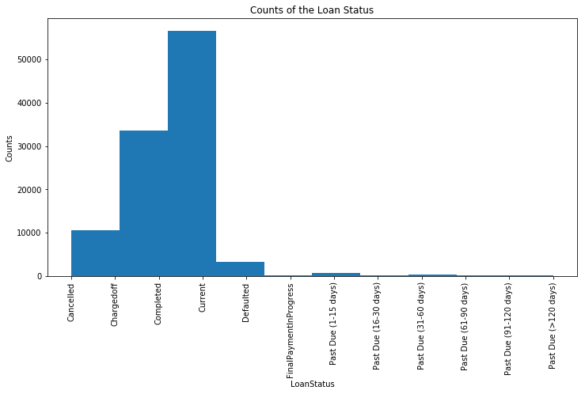

```python
## The distribution of the loan status
xL = 'LoanStatus'
yL = 'Counts'
title = 'Counts of the Loan Status'
plt.figure(figsize = (12,6))
plt.hist(x = xL, data = loan_data)
plot_labels(xL,yL,title)
plt.xticks(rotation = 90)
plt.show()
```

### Most of the loan in the dataset are current loan. However, a significant number are either completed, chargedoff or defaulted.

### What is the most common loan term

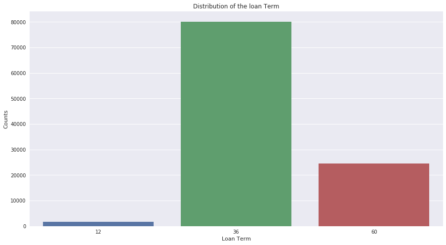

```python
# let's look at the distribution of Term
xL = 'Loan Term'
yL = 'Counts'
title = 'Distribution of the loan Term'
sns.set(rc = {'figure.figsize':(15,8)})
sns.countplot(x = 'Term', data = loan_data)
plot_labels(xL,yL,title)
plt.show()
```

### Here, majority of the customers prefers 36 month ie three years

### How many numbers of borrowers are home owners compared to borrowers without a home

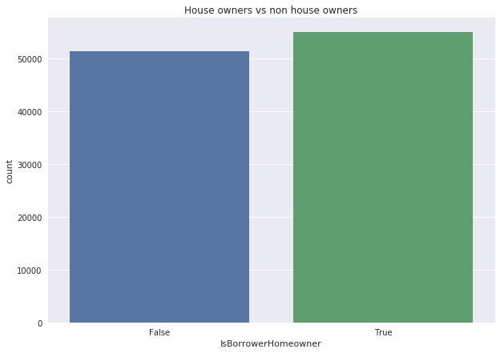

```python
# number of borowers who are home owner
sns.set(rc = {'figure.figsize':(10,7)})
sns.countplot(x = 'IsBorrowerHomeowner', data = loan_data)
plt.title('House owners vs non house owners')
plt.show()
```

### Almost equel numbers of the customers are either home owner or without a home

### What is the distribution of then loan amount?

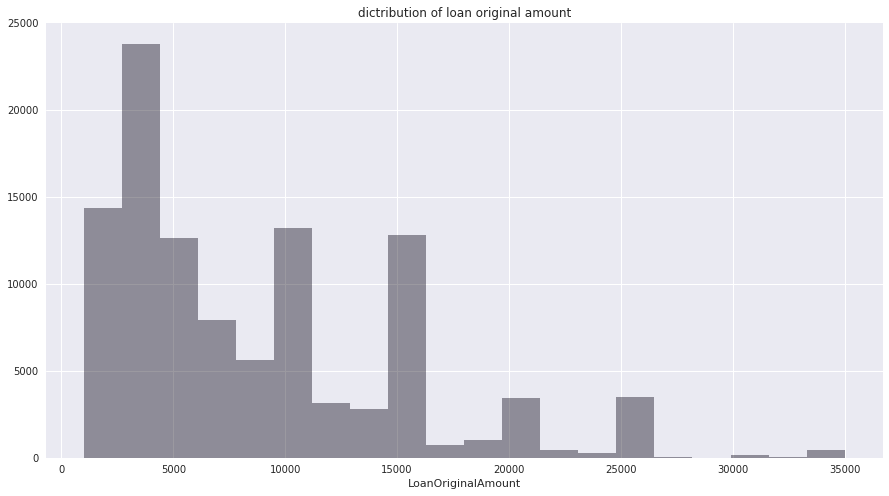

```python
#distribution of the original loan amount
sns.set(rc = {'figure.figsize':(15,8)})
sns.distplot(loan_data['LoanOriginalAmount'], bins = 20, kde = False, color = '#050012')
plt.title('dictribution of loan original amount')
plt.show()
```

#### The distribution of the loan amount disbursed around 4,000, 10,000 and 15,000. The most loaned amounts are 4,000 to 15,000.

### what is the distribution of the borrower rate?

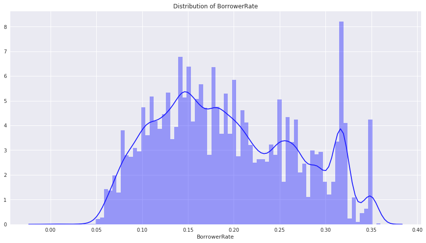

```python
#how are the borrower rate distributed distribution
sns.set(rc = {'figure.figsize':(15,8)})
sns.distplot(loan_data['BorrowerRate'], color = '#1919FF', bins = 80)
plt.title('Distribution of BorrowerRate')
plt.show()
```

#### From the distribution above, most of the loans are at 15-25% interest rate with a pick at 33%

### How is the credit score distributed?

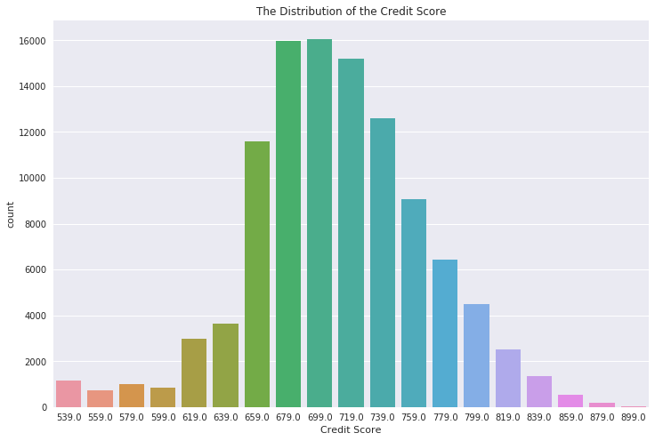

```python
# a plot of the distribution of credit score
countplot(x_var = loan_data['CreditScoreRangeUpper'], df = loan_data)
plt.xlabel('Credit Score')
plt.title('The Distribution of the Credit Score')
plt.show()
```

#### The Credit score is normally distributed with value around 699

### Discuss the distribution(s) of your variable(s) of interest. Were there any unusual points? Did you need to perform any transformations?

> Most of the loan in the dataset are current loan. However, a significant number are either completed, chargedoff or defaulted

### Of the features you investigated, were there any unusual distributions? Did you perform any operations on the data to tidy, adjust, or change the form of the data? If so, why did you do this?

> The distribution of the loan amount disbursed were around 4,000, 10,000 and 15,000. The most loaned amounts are 4,000 to 15,000. Again, the distribution of the borrower rate centres around 0.15 t0 0.20

## Bivariate Exploration

> In this section, investigate relationships between pairs of variables in your data. Make sure the variables that you cover here have been introduced in some fashion in the previous section (univariate exploration).

### Does the borrower rate affect the status of the loan?

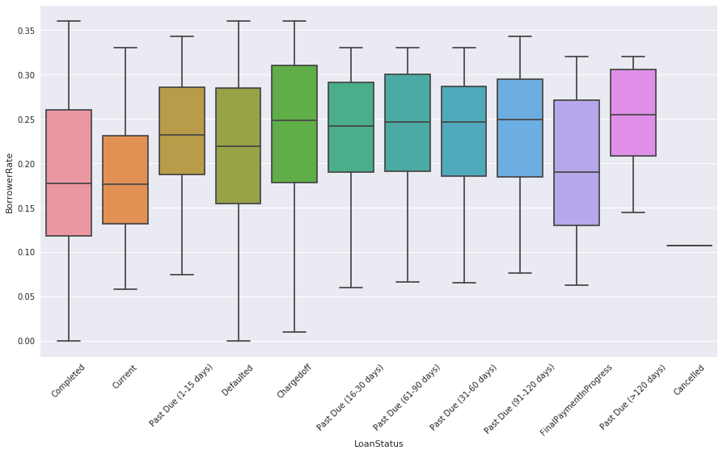

```python
# Let's check if the BorrowerRate has effect on loan status
sns.boxplot(x = 'LoanStatus',y = 'BorrowerRate', data = loan_data)
plt.xticks(rotation = 45)
plt.show()
```

### Here, it is very clear how BorrowerRate is affecting the status of the loan. Completed loans, current loan and loans at the final repayment stage have lower BorrowerRate compare to loans that are charged off, past due etc

#### How does credit score relate with the borrower rate?

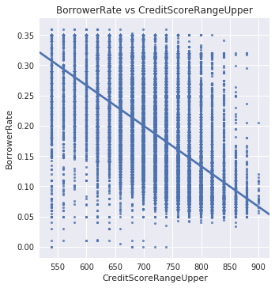

```python
plt.figure(figsize = [20,8])
sns.lmplot(x = 'CreditScoreRangeUpper', y = 'BorrowerRate', data = loan_data, scatter_kws={"s": 10})
plt.title('BorrowerRate vs CreditScoreRangeUpper')
plt.show()
```

### Does the income range determine the amount disbursed?

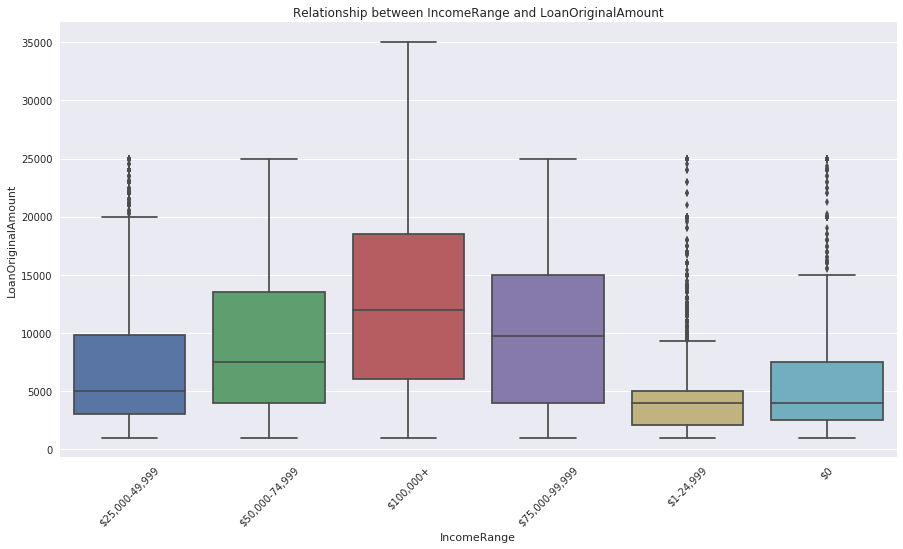

```python
sns.set(rc = {'figure.figsize':(15,8)})
sns.boxplot(x = 'IncomeRange',y = 'LoanOriginalAmount', data = loan_data)
plt.xticks(rotation = 45)
plt.title('Relationship between IncomeRange and LoanOriginalAmount')
plt.show()
```

### Clearly, the income range of a client determine the amount disbursed to the client. We can how clients with income range of 100000 dollars is disbursed a higher amount compare to 1-24999 dollars

### How does the loan amount the loan status?

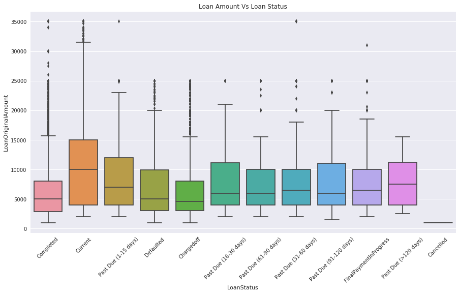

```python
# let's check how loan amount affect the loan status?

sns.boxplot(x = 'LoanStatus', y = 'LoanOriginalAmount', data = loan_data)
plt.xticks(rotation = 45)
plt.title('Loan Amount Vs Loan Status')
plt.show()
```

### What is the relationship between the original loan amount and borrower rate?

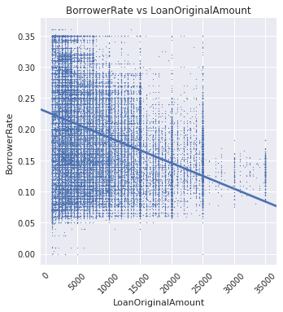

```python
plt.figure(figsize = [20,8])
sns.lmplot(x = 'LoanOriginalAmount', y = 'BorrowerRate', data = loan_data, scatter_kws={"s": 1.5})
plt.xticks(rotation = 45)
plt.title('BorrowerRate vs LoanOriginalAmount')
plt.show()
```

### Suprisingly, the BorrowerRate decreases as the Loan Amount Increases

### What is the relationship between borrower rate and borrower APr

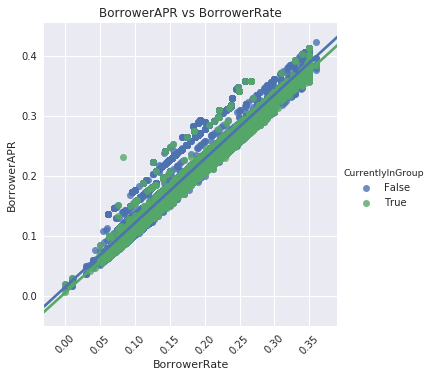

```python
# does the loan term has any effect on the loan status?
sns.set(rc = {'figure.figsize':(15,8)})
sns.lmplot(x = 'BorrowerRate', y = 'BorrowerAPR',hue = 'CurrentlyInGroup', data = loan_data)
plt.xticks(rotation = 45)
plt.title('BorrowerAPR vs BorrowerRate')
plt.show()
```

### Did you observe any interesting relationships between the other features (not the main feature(s) of interest)?

> There is a clear correlation between BorrowerAPR and BorrowerRate. The income range also affected the amount of loan disbursed. Whereas people with lower incomeRange were disburesd a lower amount, others with higher income were disbursed a higher amount. This makes sense as the income of a client can affect loan repayment either positively or negatively.

## Multivariate Exploration

### How does the credit score affect the loan amount on borrower rate

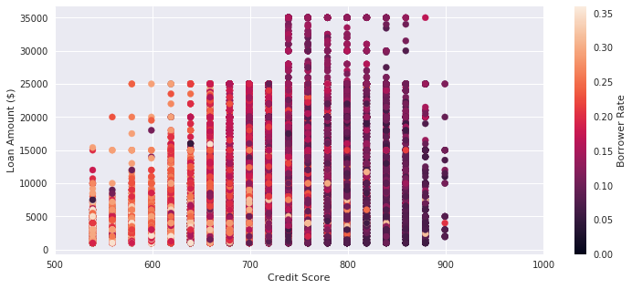

```python
#Scatter plot using original LoanOriginalAmount
plt.figure(figsize=[12,5])
plt.scatter(data=loan_data, x='CreditScoreRangeUpper', y='LoanOriginalAmount', c='BorrowerRate');
plt.colorbar(label='Borrower Rate');
plt.xlim(500, 1000);
plt.ylabel('Loan Amount ($)');
plt.xlabel('Credit Score');
```

#### As the credit score increases, the borrower Rate decreases

### What is the relationship between borrowerAPR, StatedMonthlyIncome, LoanOriginalAmount?

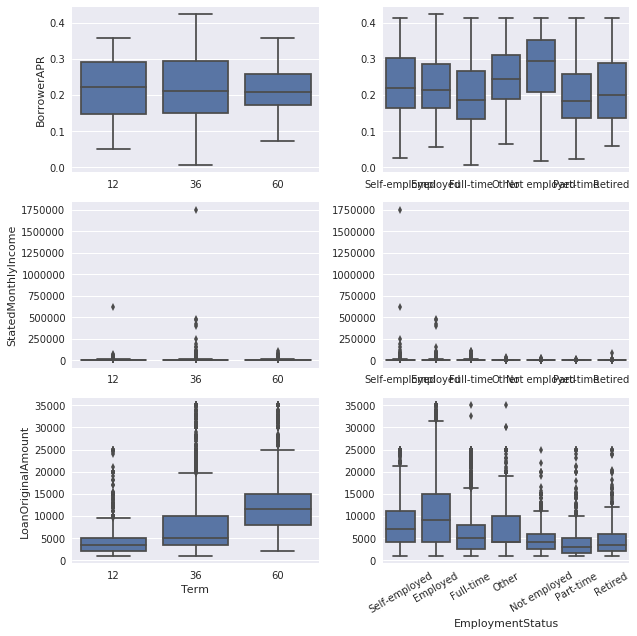

```python
# plot matrix of numeric features against categorical features.

def box_func(x, y, **kwargs):
    """ This function will create a pair grid box plot """
    color = sns.color_palette()[0]
    sns.boxplot(x, y, color = color)

plt.figure(figsize = [10, 10])
g = sns.PairGrid(data = loan_data, y_vars = ['BorrowerAPR', 'StatedMonthlyIncome', 'LoanOriginalAmount'],
                x_vars = ['Term','EmploymentStatus'], size = 3, aspect = 1.5)
g.map(box_func);
plt.xticks(rotation=30)
plt.tight_layout();
```

#### From the plots above, it is very clear that the original loan amout increases with the term of the loan and as expected, the highest loan amount was disbursed to the employed. The borrowerAPR on the other hand, was slightly higher for a short term loan compare to the long term loan.

### How does the borrower rate affect the loan status in terms of whether a client is a home owner or not?

```
Text(0.5,1,'LoanStatus Vs BorrowerAPR Vs IsBorrowerHomeowner ')
```

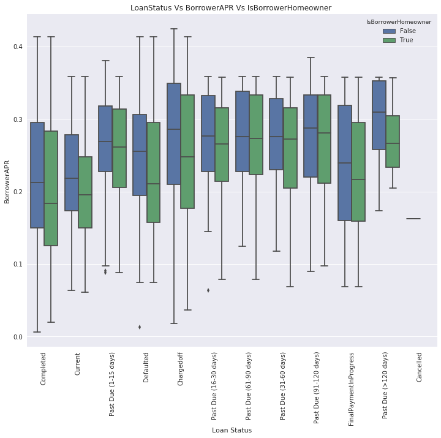

```python
# LoanStatus Vs BorrowerAPR VS IsBorrowerHomeowner
plt.figure(figsize=[12,10])
sns.boxplot(x="LoanStatus", y="BorrowerAPR", hue = 'IsBorrowerHomeowner', data=loan_data);
plt.xticks(rotation = 90)
plt.xlabel('Loan Status')
plt.ylabel('BorrowerAPR')
plt.title('LoanStatus Vs BorrowerAPR Vs IsBorrowerHomeowner ')
```

### Were there any interesting or surprising interactions between features?

> Surprisingly, home owners have lower APR compare to those without a home. This is one feature I thought will be the other way round.

## References

1. https://stackoverflow.com/questions/36901154/how-export-a-jupyter-notebook-to-html-from-the-command-line
2. http://seaborn.pydata.org/tutorial.html
3. https://seaborn.pydata.org/generated/seaborn.PairGrid.html